# Backtesting a MACD Trading Strategy

Tan Zheng Liang

2022-12-06

## 1 Introduction

In this project, I backtested the Moving Average Convergence/Divergence (MACD) trading strategy. The MACD indicator requires 4 main inputs, which are the periods for the fast and slow moving averages, the period for the signal moving average and the type of moving averages to use. The inputs would mostly depend on the trader’s trading horizon (e.g. intraday, scalping, swing trading etc.). For me, I prefer to use the exponential moving averages with the 20-period, 50-period and 5-period as my fast, slow and signal EMAs.

The results in this project were based on the assumptions of zero trading costs and that trades could be filled at the opening prices at any point in time. Therefore, any excess return that was achieved through the MACD trading strategy may not be a good proxy of actual performance. Furthermore, past performance is not indicative of future performance.

## 2 Packages Required

```r
library(tidyquant) # Loads quantmod, PerformanceAnalytics and TTR packages
library(tidyverse) # Loads dplyr and ggplot2 packages (data manipulation and plotting)
```

## 3 Methodology and Data

In my previous project [Backtesting a 5-day and 20-day Moving Average Trading Strategy](https://zheng-liang.github.io/Portfolio%20Optimization%20and%20Back-testing%20Trading%20Strategies/Backtesting%20a%205-day%20and%2020-day%20Moving%20Average%20Trading%20Strategy.html), I implemented a moving average trading strategy on Apple Inc. (AAPL), Exxon Mobil Corporation (XOM), Microsoft Corporation (MSFT), Procter & Gamble Company (PG) and Merck & Co. Inc. (MRK). I would use these same stocks, with price data from January 2018 to October 2022, for my MACD trading strategy to allow for some comparison of trading results.

The steps for the trading strategy are:

1. Create the MACD indicator with a 20-day fast moving average and a 50-day slow moving average, with a 5-day signal moving average
2. I would buy and hold the stock if the MACD crosses and stays above the signal line and the MACD or signal line is upward sloping
3. I would exit my long position if the MACD crosses and stays under the signal line and the MACD or signal line is downward sloping

To determine if the lines are upward sloping, I would find the difference of the current MACD or signal value from the value 5 periods ago. I would buy or sell the stocks at the opening price the next trading day after the trading signal is established. I assumed zero trading costs and that all trades can be filled at any point in time, which is not practical, but allowed me to test the effectiveness of the strategy in a simple manner.

The historical stock prices can be obtained using **`quantmod::getSymbols()`**.

```r
# Set start and end date for data retrieval
startdate <- as.Date("2018-01-01")
enddate <- as.Date("2022-11-01")

# Create vector of tickers
ticker <- c("AAPL", "XOM", "MSFT", "PG", "MRK")

dat <- list()

for (t in seq(ticker)) {
  dat[[ticker[t]]] <- quantmod::getSymbols(Symbols = ticker[t], src = "yahoo", auto.assign = FALSE,
                                           from = startdate, to = enddate, periodicity = "daily")
}

lapply(dat, head, 3)
```

```
## $AAPL
##            AAPL.Open AAPL.High AAPL.Low AAPL.Close AAPL.Volume AAPL.Adjusted
## 2018-01-02   42.5400   43.0750   42.315    43.0650   102223600      40.95049
## 2018-01-03   43.1325   43.6375   42.990    43.0575   118071600      40.94336
## 2018-01-04   43.1350   43.3675   43.020    43.2575    89738400      41.13354
##
## $XOM
##            XOM.Open XOM.High XOM.Low XOM.Close XOM.Volume XOM.Adjusted
## 2018-01-02    83.82    85.20   83.66     85.03   11469300     65.37910
## 2018-01-03    85.16    86.97   84.82     86.70   13957700     66.66312
## 2018-01-04    86.79    87.22   86.43     86.82   10863000     66.75541
##
## $MSFT
##            MSFT.Open MSFT.High MSFT.Low MSFT.Close MSFT.Volume MSFT.Adjusted
## 2018-01-02     86.13     86.31    85.50      85.95    22483800      80.94041
## 2018-01-03     86.06     86.51    85.97      86.35    26061400      81.31708
## 2018-01-04     86.59     87.66    86.57      87.11    21912000      82.03278
##
## $PG
##            PG.Open PG.High PG.Low PG.Close PG.Volume PG.Adjusted
## 2018-01-02   91.92   91.93  90.55    90.65   7558900    79.11253
## 2018-01-03   90.73   91.09  90.52    90.54   5863600    79.01653
## 2018-01-04   90.83   91.77  90.61    91.18   6322500    79.57509
##
## $MRK
##            MRK.Open MRK.High  MRK.Low MRK.Close MRK.Volume MRK.Adjusted
## 2018-01-02 53.99809 54.15076 53.48282  53.64504   10556504     46.21743
## 2018-01-03 53.65458 53.68321 53.39695  53.56870   11090460     46.15166
## 2018-01-04 53.85496 54.79008 53.79771  54.43702   15751650     46.89977
```

## 4 MACD Trading Strategy

The MACD and signal values can be calculated using **`TTR::MACD()`**. I also added a time component and included the regression to find the slope of the MACD and signal lines.

```r
# Create MACD and signal values, time component and regress to find slops
for (i in seq(dat)) {
  dat[[i]] <- cbind(dat[[i]], TTR::MACD(x = quantmod::Cl(dat[[i]]),
                                        nFast = 20,
                                        nSlow = 50,
                                        nSig = 5,
                                        maType = "EMA"))

  dat[[i]]$MACDslope <- diff(dat[[i]]$macd, lag = 5)

  dat[[i]]$SIGslope <- diff(dat[[i]]$signal, lag = 5)
}
```

Generate trading signals by checking if MACD is above the signal line and if either MACD or the signal line is upward sloping:

```r
# Remove rows with missing data
dat2 <- lapply(dat, na.omit)

# Use for loops to determine if conditions were met
for (i in seq(dat2)) {
  dat2[[i]]$trade.signal <- (dat2[[i]]$macd > dat2[[i]]$signal) & (dat2[[i]]$MACDslope > 0) | (dat2[[i]]$SIGslope > 0)
}
```

Since I buy or sell at the opening price, I would calculate returns based on these prices for simplicity.

```r
# Calculate returns using opening price and lag the trade.signal twice for backtesting
# Reason: buy the next day after the trade.signal and returns are calculated using previous day value
for (i in seq(dat2)) {
  dat2[[i]]$MACDreturn <- Return.calculate(prices = Op(dat2[[i]]), method = "log") * Lag(dat2[[i]]$trade.signal, k = 2)
}
```

### 4.1 Plot of Cumulative Return

I plotted the returns from trading each stock against the returns earned by holding the stock over the period.

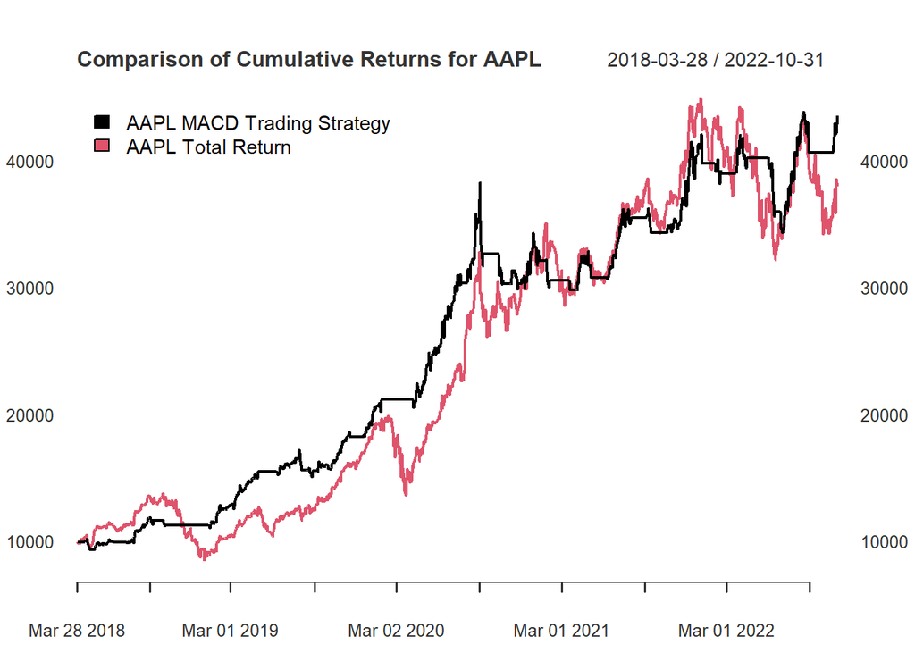

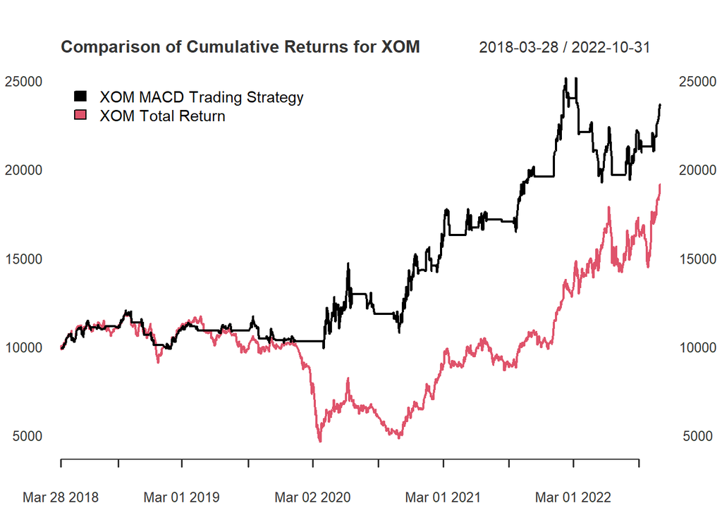

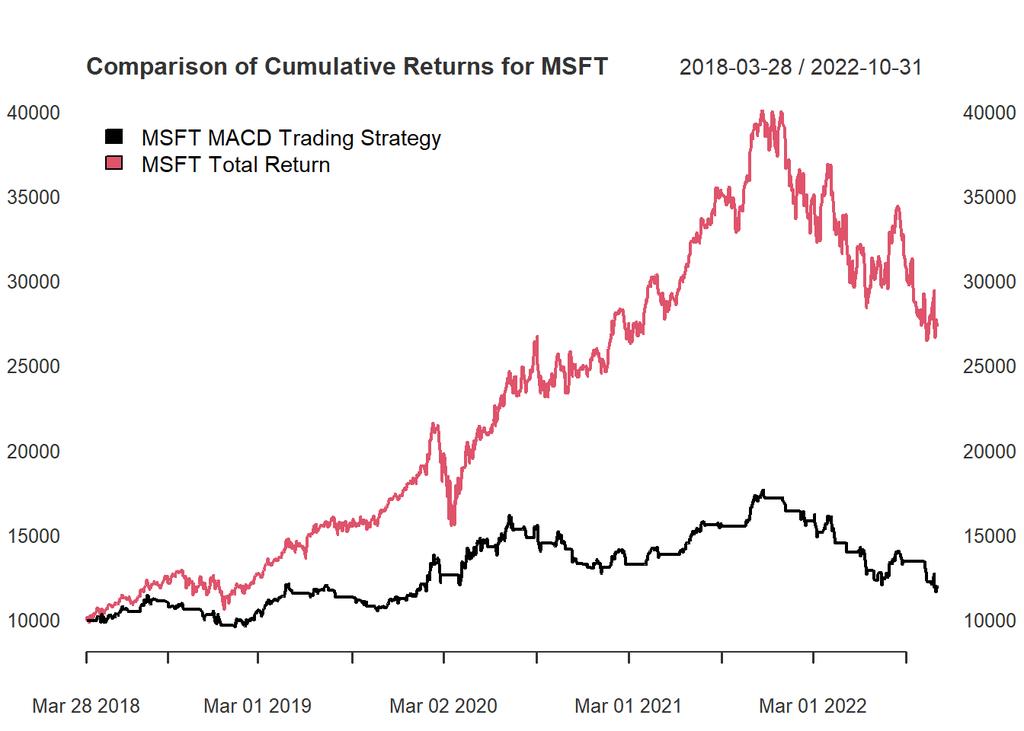

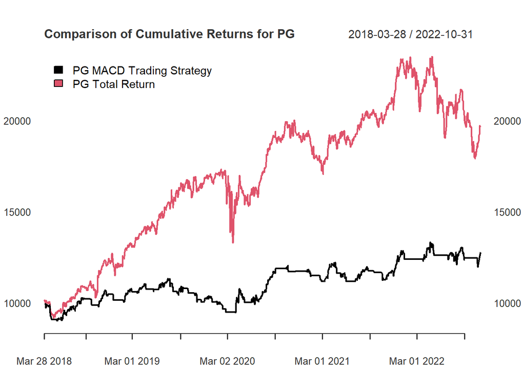

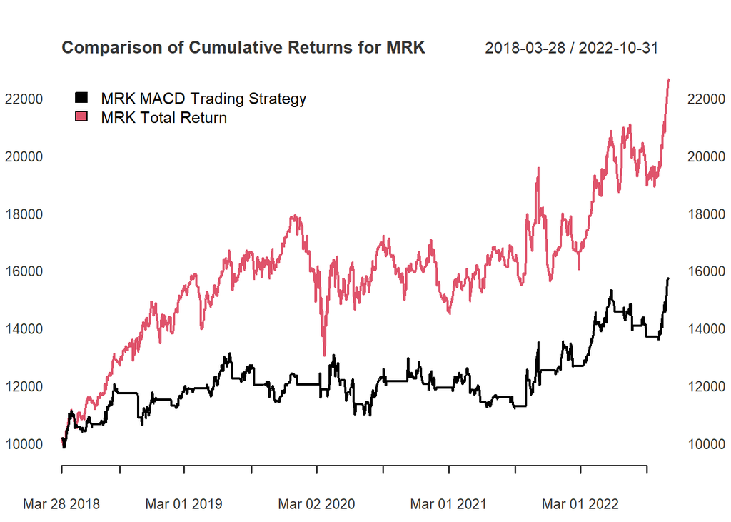

```r
# Calculate the returns earned by holding the stocks using adjusted prices
# Adjusted prices include splits and dividends information
for (i in seq(dat2)) {
  dat2[[i]]$total.return <- Return.calculate(prices = Ad(dat2[[i]]), method = "log")
}

# Save the cumulative return data in a separate dataframe
return.plot <- NULL

for (i in seq(dat2)) {
  return.plot <- cbind(return.plot,
                       10000 * exp(cumsum(na.omit(dat2[[i]]$MACDreturn))),
                       10000 * exp(cumsum(na.omit(dat2[[i]]$total.return))))
}

colnames(return.plot) <- paste(rep(ticker, each = 2),
                               rep(c("MACD Trading Strategy", "Total Return"), length(dat2)))

for (i in seq(from = 1, to = ncol(return.plot), by = 2)) {
  plot(return.plot[, c(i, i+1)],
       main = paste("Comparison of Cumulative Returns for", rep(ticker, each = 2)[i]),
       legend.loc = "topleft", grid.col = NA) %>%
    print()
}
```

### 4.2 Table of Annualized Metrics

Calculate the annualized returns and standard deviation for comparison of performance using **`PerformanceAnalytics::table.AnnualizedReturns()`**.

```r
for (i in seq(dat2)) {
  PerformanceAnalytics::table.AnnualizedReturns(R = dat2[[i]][, c("MACDreturn","total.return")],
                                                scale = 252,
                                                Rf = 0.03/252,
                                                geometric = FALSE) %>%
    `colnames<-`(paste(rep(ticker[i], 2),
                       rep(c("MACD Trading Strategy", "Total Return")))) %>%
    print()
}
```

```
##                           AAPL MACD Trading Strategy AAPL Total Return
## Annualized Return                             0.3211            0.2911
## Annualized Std Dev                            0.2007            0.3358
## Annualized Sharpe (Rf=3%)                     1.4505            0.7775
##                           XOM MACD Trading Strategy XOM Total Return
## Annualized Return                            0.1882           0.1420
## Annualized Std Dev                           0.2600           0.3452
## Annualized Sharpe (Rf=3%)                    0.6084           0.3244
##                           MSFT MACD Trading Strategy MSFT Total Return
## Annualized Return                             0.0416            0.2189
## Annualized Std Dev                            0.1951            0.3079
## Annualized Sharpe (Rf=3%)                     0.0592            0.6135
##                           PG MACD Trading Strategy PG Total Return
## Annualized Return                           0.0543          0.1474
## Annualized Std Dev                          0.1221          0.2216
## Annualized Sharpe (Rf=3%)                   0.1989          0.5298
##                           MRK MACD Trading Strategy MRK Total Return
## Annualized Return                            0.0987           0.1784
## Annualized Std Dev                           0.1718           0.2345
## Annualized Sharpe (Rf=3%)                    0.4002           0.6331
```

## 5 Final Remarks

Similar to the moving average trading strategy I tested previously, the MACD trading strategy worked for some stocks while performing poorly for others. This again showed that a trading strategy does not work equally for all stocks. Despite achieving excess returns for AAPL and XOM, it was obtained under the assumption of zero transaction costs. It would be safer to assume that the transaction costs would significantly reduce the returns from active trading, depending on the frequency of the trades made.